# Predict the Flat Resale Prices in Singapore

## 1 Problem Description

Investing in Flats is the biggest investment for most households in cities like Singapore which is very small but heavily urbanised. Therefore, being able to accurately value the flat prices will not only facilitate market transactions by providing valuable guidance for all market participants (be it home owners, home buyers, landlords, tenants or banks that underwrite mortgages), but also provide useful insights for policy makers and government authorities in understanding the current state of the economy.

In this competition, you are expected to create an analytical and modelling framework to predict the flat resale prices based on the quantitative and qualitative features provided in the dataset while answering other questions too cited below.

##### Evaluation Metric: Consider the ‘RMSE’ as the error metric for regression task to tune the model

##### For Information: Singapore Flats have 99-year lease

### 1.1 Import Libraries

```python
import pandas as pd
import numpy as np
import re
from fancyimpute import KNN
from sklearn.preprocessing import LabelEncoder
from sklearn.metrics import mean_squared_error,r2_score,mean_absolute_error
from sklearn.model_selection import GridSearchCV
import seaborn as sns
import matplotlib.pyplot as plt
import requests
import json
```

```python
import warnings
warnings.filterwarnings('ignore')
#Warning won't be displayed on the notebook
```

### 1.2 Reading the Files

```python
#Reading all the Files
train1 = pd.read_csv("data/train1-1568365584614.csv")
train2 = pd.read_csv("data/train2-1568365601370.csv")
train3 = pd.read_csv("data/train3-1568365612890.csv")
train4 = pd.read_csv("data/building_to_mrt_distance-1568365651170.csv")
```

```python
test = pd.read_csv("data/test-1568365637039.csv")
original_test = test['uniqueID']
```

### 1.3 Data Description

```python
datasets = [train1,train2,train3,train4,test]
train1.name = 'train1'
train2.name = 'train2'
train3.name = 'train3'
train4.name = 'train4'
test.name = "test"
for i in datasets:
    print("\033[1m"+"\nInformation for "+i.name+ "\033[0;0m") # \033[1m & \033[0;0m is used to make the text bold
    print("\033[1m"+"\nDimensions"+ "\033[0;0m",i.shape)
    print("\033[1m"+"\nCoulumns\n"+ "\033[0;0m",i.columns)
    print(u'\u2500' * 100)
```

```
Information for train1

Dimensions (52203, 11)

Coulumns
 Index(['month', 'town', 'flat_type', 'block', 'street_name', 'storey_range',
       'floor_area_sqm', 'flat_model', 'lease_commence_date', 'resale_price',
       'uniqueID'],
      dtype='object')
────────────────────────────────────────────────────────────────────────────────────────────────────

Information for train2

Dimensions (37153, 12)

Coulumns
 Index(['month', 'town', 'flat_type', 'block', 'street_name', 'storey_range',
       'floor_area_sqm', 'flat_model', 'lease_commence_date',
       'remaining_lease', 'resale_price', 'uniqueID'],
      dtype='object')
────────────────────────────────────────────────────────────────────────────────────────────────────

Information for train3

Dimensions (32578, 12)

Coulumns
 Index(['month', 'town', 'flat_type', 'block', 'street_name', 'storey_range',
       'floor_area_sqm', 'flat_model', 'lease_commence_date',
       'remaining_lease', 'resale_price', 'uniqueID'],
      dtype='object')
────────────────────────────────────────────────────────────────────────────────────────────────────

Information for train4

Dimensions (8811, 120)

Coulumns
 Index(['Building', 'Jurong East MRT station', 'Bukit Batok MRT station',
       'Bukit Gombak MRT station', 'Choa Chu Kang MRT station',
       'Yew Tee MRT station', 'Kranji MRT station', 'Marsiling MRT station',
       'Woodlands MRT station', 'Admiralty MRT station',
       ...
       'Bendemeer MRT station', 'Geylang Bahru MRT Station',
       'Mattar MRT station', 'Ubi MRT station', 'Kaki Bukit MRT Station',
       'Bedok North MRT station', 'Bedok Reservoir MRT station',
       'Tampines West MRT station', 'Tampines East MRT station',
       'Upper Changi MRT station'],
      dtype='object', length=120)
────────────────────────────────────────────────────────────────────────────────────────────────────

Information for test

Dimensions (21846, 11)

Coulumns
 Index(['month', 'town', 'flat_type', 'block', 'street_name', 'storey_range',
       'floor_area_sqm', 'flat_model', 'lease_commence_date',
       'remaining_lease', 'uniqueID'],
      dtype='object')
────────────────────────────────────────────────────────────────────────────────────────────────────
```

#### 1.4 Null Values Check

```python
for i in datasets:
    print("\033[1m"+"\nNull Values Information for "+i.name+ "\033[0;0m") # \033[1m & \033[0;0m is used to make the text bold
#     print(i.isnull().sum())
    print("\033[1m"+"Total Null values in "+ i.name+"\033[0;0m"+" : ", i.isnull().sum().sum())
    print(u'\u2500' * 100)
```

```
Null Values Information for train1
Total Null values in train1 :  0
────────────────────────────────────────────────────────────────────────────────────────────────────

Null Values Information for train2
Total Null values in train2 :  0
────────────────────────────────────────────────────────────────────────────────────────────────────

Null Values Information for train3
Total Null values in train3 :  0
────────────────────────────────────────────────────────────────────────────────────────────────────

Null Values Information for train4
Total Null values in train4 :  0
────────────────────────────────────────────────────────────────────────────────────────────────────

Null Values Information for test
Total Null values in test :  0
────────────────────────────────────────────────────────────────────────────────────────────────────
```

### 1.5 Data Preview

```python
train1.head()
```

|  | month | town | flat_type | block | street_name | storey_range | floor_area_sqm | flat_model | lease_commence_date | resale_price | uniqueID |
| --- | --- | --- | --- | --- | --- | --- | --- | --- | --- | --- | --- |
| 0 | 2012-03 | ANG MO KIO | 2 ROOM | 172 | ANG MO KIO AVE 4 | 06 TO 10 | 45.0 | Improved | 1986 | 250000.0 | 100000 |
| 1 | 2012-03 | ANG MO KIO | 2 ROOM | 510 | ANG MO KIO AVE 8 | 01 TO 05 | 44.0 | Improved | 1980 | 265000.0 | 100001 |
| 2 | 2012-03 | ANG MO KIO | 3 ROOM | 610 | ANG MO KIO AVE 4 | 06 TO 10 | 68.0 | New Generation | 1980 | 315000.0 | 100002 |
| 3 | 2012-03 | ANG MO KIO | 3 ROOM | 474 | ANG MO KIO AVE 10 | 01 TO 05 | 67.0 | New Generation | 1984 | 320000.0 | 100003 |
| 4 | 2012-03 | ANG MO KIO | 3 ROOM | 604 | ANG MO KIO AVE 5 | 06 TO 10 | 67.0 | New Generation | 1980 | 321000.0 | 100004 |

```python
train2.head()
```

|  | month | town | flat_type | block | street_name | storey_range | floor_area_sqm | flat_model | lease_commence_date | remaining_lease | resale_price | uniqueID |
| --- | --- | --- | --- | --- | --- | --- | --- | --- | --- | --- | --- | --- |
| 0 | 2015-01 | ANG MO KIO | 3 ROOM | 174 | ANG MO KIO AVE 4 | 07 TO 09 | 60.0 | Improved | 1986 | 70 | 255000.0 | 152203 |
| 1 | 2015-01 | ANG MO KIO | 3 ROOM | 541 | ANG MO KIO AVE 10 | 01 TO 03 | 68.0 | New Generation | 1981 | 65 | 275000.0 | 152204 |
| 2 | 2015-01 | ANG MO KIO | 3 ROOM | 163 | ANG MO KIO AVE 4 | 01 TO 03 | 69.0 | New Generation | 1980 | 64 | 285000.0 | 152205 |
| 3 | 2015-01 | ANG MO KIO | 3 ROOM | 446 | ANG MO KIO AVE 10 | 01 TO 03 | 68.0 | New Generation | 1979 | 63 | 290000.0 | 152206 |
| 4 | 2015-01 | ANG MO KIO | 3 ROOM | 557 | ANG MO KIO AVE 10 | 07 TO 09 | 68.0 | New Generation | 1980 | 64 | 290000.0 | 152207 |

```python
train3.head()
```

|  | month | town | flat_type | block | street_name | storey_range | floor_area_sqm | flat_model | lease_commence_date | remaining_lease | resale_price | uniqueID |
| --- | --- | --- | --- | --- | --- | --- | --- | --- | --- | --- | --- | --- |
| 0 | 2017-01 | ANG MO KIO | 2 ROOM | 406 | ANG MO KIO AVE 10 | 10 TO 12 | 44.0 | Improved | 1979 | 61 years 04 months | 232000.0 | 189356 |
| 1 | 2017-01 | ANG MO KIO | 3 ROOM | 108 | ANG MO KIO AVE 4 | 01 TO 03 | 67.0 | New Generation | 1978 | 60 years 07 months | 250000.0 | 189357 |
| 2 | 2017-01 | ANG MO KIO | 3 ROOM | 602 | ANG MO KIO AVE 5 | 01 TO 03 | 67.0 | New Generation | 1980 | 62 years 05 months | 262000.0 | 189358 |
| 3 | 2017-01 | ANG MO KIO | 3 ROOM | 465 | ANG MO KIO AVE 10 | 04 TO 06 | 68.0 | New Generation | 1980 | 62 years 01 month | 265000.0 | 189359 |
| 4 | 2017-01 | ANG MO KIO | 3 ROOM | 601 | ANG MO KIO AVE 5 | 01 TO 03 | 67.0 | New Generation | 1980 | 62 years 05 months | 265000.0 | 189360 |

```python
train4.head()
```

|  | Building | Jurong East MRT station | Bukit Batok MRT station | Bukit Gombak MRT station | Choa Chu Kang MRT station | Yew Tee MRT station | Kranji MRT station | Marsiling MRT station | Woodlands MRT station | Admiralty MRT station | ... | Bendemeer MRT station | Geylang Bahru MRT Station | Mattar MRT station | Ubi MRT station | Kaki Bukit MRT Station | Bedok North MRT station | Bedok Reservoir MRT station | Tampines West MRT station | Tampines East MRT station | Upper Changi MRT station |
| --- | --- | --- | --- | --- | --- | --- | --- | --- | --- | --- | --- | --- | --- | --- | --- | --- | --- | --- | --- | --- | --- |
| 0 | ANCHORVALE ST BLK 331C | 17818.84265 | 16471.03384 | 15856.79247 | 16199.22480 | 15808.72792 | 14570.109930 | 13485.500120 | 12369.979820 | 11061.899320 | ... | 9584.39327 | 8494.000192 | 7640.691202 | 7398.618897 | 7079.585070 | 7440.940807 | 8107.447171 | 7743.354078 | 8438.549604 | 9950.182657 |
| 1 | PUNGGOL WAY BLK 266B | 19092.61457 | 17694.05674 | 17032.15623 | 17205.95322 | 16731.88625 | 15248.533120 | 14065.860790 | 12863.730930 | 11445.713010 | ... | 10932.92815 | 9808.425468 | 8872.302279 | 8425.747280 | 7957.972942 | 8163.873942 | 8589.377565 | 8042.543847 | 8366.769609 | 9996.575353 |
| 2 | YISHUN AVE 9 BLK 318A | 15919.39969 | 14166.65357 | 13182.50154 | 12293.68148 | 11439.72263 | 9122.636441 | 7722.266883 | 6368.157244 | 4795.908711 | ... | 13570.68606 | 12907.865810 | 12661.750790 | 13179.447730 | 13208.994580 | 13791.613210 | 14675.215580 | 14401.138090 | 15072.755350 | 16621.097390 |
| 3 | YISHUN AVE 9 BLK 318B | 15903.04510 | 14152.90288 | 13171.66285 | 12296.13129 | 11447.44104 | 9144.786709 | 7748.983596 | 6398.540744 | 4831.224121 | ... | 13515.78029 | 12851.563270 | 12604.181940 | 13121.274190 | 13151.040900 | 13734.103470 | 14618.776730 | 14345.977870 | 15020.740460 | 16567.813760 |
| 4 | YISHUN AVE 9 BLK 315A | 15705.88647 | 13955.91314 | 12975.36314 | 12109.29884 | 11267.18726 | 8991.283610 | 7607.087576 | 6267.390055 | 4716.850722 | ... | 13402.90599 | 12752.522990 | 12524.591610 | 13068.535130 | 13115.059640 | 13710.617970 | 14613.647670 | 14356.366340 | 15058.662370 | 16595.614410 |

5 rows × 120 columns

```python
test.head()
```

|  | month | town | flat_type | block | street_name | storey_range | floor_area_sqm | flat_model | lease_commence_date | remaining_lease | uniqueID |
| --- | --- | --- | --- | --- | --- | --- | --- | --- | --- | --- | --- |
| 0 | 2018-08 | ANG MO KIO | 2 ROOM | 323 | ANG MO KIO AVE 3 | 01 TO 03 | 44.0 | Improved | 1977 | 57 years 10 months | 221934 |
| 1 | 2018-08 | ANG MO KIO | 3 ROOM | 220 | ANG MO KIO AVE 1 | 07 TO 09 | 82.0 | New Generation | 1977 | 57 years 11 months | 221935 |
| 2 | 2018-08 | ANG MO KIO | 3 ROOM | 220 | ANG MO KIO AVE 1 | 07 TO 09 | 67.0 | New Generation | 1977 | 57 years 11 months | 221936 |
| 3 | 2018-08 | ANG MO KIO | 3 ROOM | 445 | ANG MO KIO AVE 10 | 01 TO 03 | 67.0 | New Generation | 1979 | 60 years 01 month | 221937 |
| 4 | 2018-08 | ANG MO KIO | 3 ROOM | 471 | ANG MO KIO AVE 10 | 01 TO 03 | 67.0 | New Generation | 1979 | 59 years 11 months | 221938 |

## 2 Exploratory Data Analysis (on merged data)

```python
data_analyse = pd.read_csv("data_analysis_raw.csv")
```

### 2.1 Correlation Plot

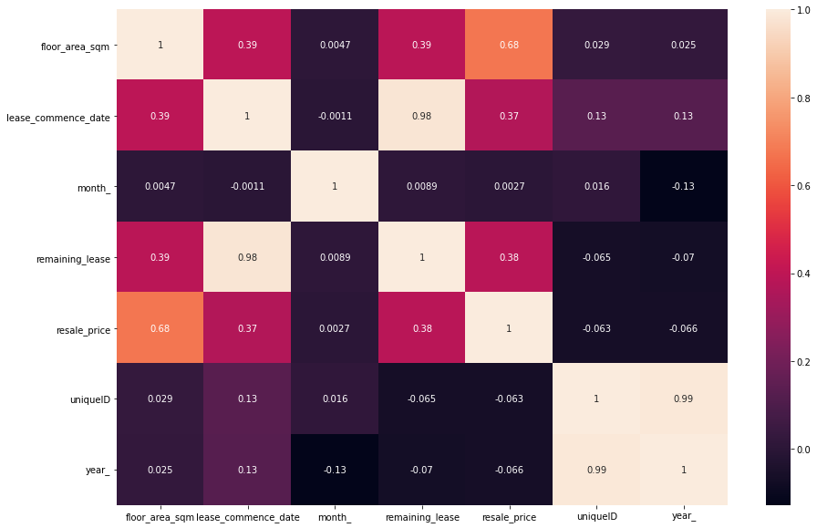

```python
plt.figure(figsize=(15,10))
sns.heatmap(data_analyse.corr(),annot=True)
```

### 2.2 Univariate Analysis

#### 2.2.1 Numerical Variables

###### 2.2.1.1 resale_price

```
Resale Price Histogram
```

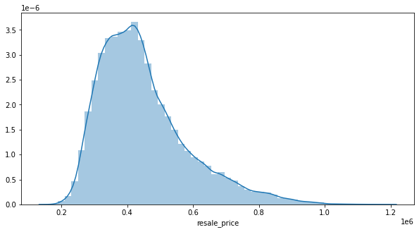

```python
print("Resale Price Histogram")
plt.figure(figsize=(10,5))
sns.distplot(data_analyse['resale_price'])
```

There's some positive skewness on resale price histogram.

#### 2.2.2 Categorical Variables

##### 2.2.2.1 flat_type

```
flat_type Countplot
```

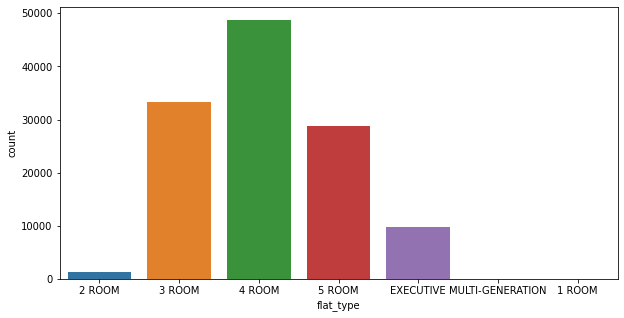

```python
print("flat_type Countplot")
plt.figure(figsize=(10,5))
sns.countplot(data_analyse.flat_type)
```

4 ROOM Flats have higher availability than any other type of flat_type

##### 2.2.2.2 flat_model

```
flat_model Countplot
```

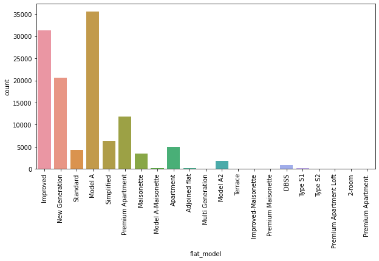

```python
print("flat_model Countplot")
plt.figure(figsize=(10,5))
plt.xticks(rotation=90)
sns.countplot(data_analyse.flat_model)
```

Model A which has the most no of flats available based on flat_model

##### 2.2.2.3 remaining_lease

```
remaining_lease Countplot
```

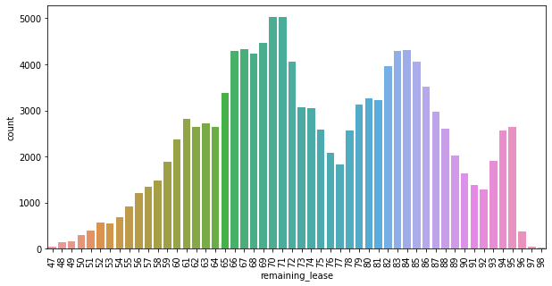

```python
print("remaining_lease Countplot")
plt.figure(figsize=(10,5))
plt.xticks(rotation=90)
sns.countplot(data_analyse.remaining_lease)
```

##### 2.2.2.4 storey_range

```
storey_range Countplot
```

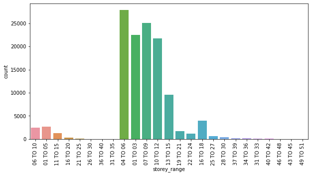

```python
print("storey_range Countplot")
plt.figure(figsize=(10,5))
plt.xticks(rotation=90)
sns.countplot(data_analyse.storey_range)
```